# SI 618 - Homework #6: Machine Learning 1

Version 2021.03.21.2.CT

In this homework exercise you will apply the machine learning techniques we've covered so far: linear regression, machine learning pipeline, agglomerative clustering, k-means clustering, and t-SNE.

We will be using [graduate admissions data](https://www.kaggle.com/mohansacharya/graduate-admissions).

This is a fairly involved homework assignment and we *strongly* urge you to not leave this to the last minute. We suggest that you try to work on this assignment over several days.

### The total score for this assignment will be 100 points, consisting of:

- 10 pt: Overall quality of spelling, grammar, punctuation, etc. of written sentences. ([Guide](https://drive.google.com/file/d/1L0P7xJwjUGBvyb49mL3dw1Bt7hzRTiTl/view))
- 10 pt: Code is written in [PEP 8](https://www.python.org/dev/peps/pep-0008/) style.
- 80 pt: Homework questions.

```python
MY_UNIQNAME = 'natmay' # fill this in with your uniqname
# Do not modify the next three lines
import numpy as np
MY_UNIQHASH = hash(MY_UNIQNAME) & 2**32-1
np.random.seed(MY_UNIQHASH)
print(f"Random seed set to {MY_UNIQHASH}")
```

```
Random seed set to 3776991214
```

```python
import pandas as pd
import numpy as np
```

```python
admit = pd.read_csv('https://raw.githubusercontent.com/umsi-data-science/data/main/Admission_Predict.csv',
                    index_col="Serial No.")
```

```python
admit.shape
```

```
(400, 8)
```

```python
admit.head()
```

| Serial No. | GRE Score | TOEFL Score | University Rating | SOP | LOR | CGPA | Research | Chance of Admit |
| --- | --- | --- | --- | --- | --- | --- | --- | --- |
| 1 | 337 | 118 | 4 | 4.5 | 4.5 | 9.65 | 1 | 0.92 |
| 2 | 324 | 107 | 4 | 4.0 | 4.5 | 8.87 | 1 | 0.76 |
| 3 | 316 | 104 | 3 | 3.0 | 3.5 | 8.00 | 1 | 0.72 |
| 4 | 322 | 110 | 3 | 3.5 | 2.5 | 8.67 | 1 | 0.80 |
| 5 | 314 | 103 | 2 | 2.0 | 3.0 | 8.21 | 0 | 0.65 |

```python
# clean up column names
admit.rename(columns={
    "Chance of Admit ": "admit_ch",
    "GRE Score": "gre",
    "TOEFL Score": "toefl",
    "University Rating": "rating",
    "LOR ": "lor",
}, inplace=True)
```

```python
import seaborn as sns
```

## Task 1 (5 points):

Perform basic exploratory data analyses on the variables in this dataframe. Your work should include both numerical **and** graphical overviews of the data. The `multiplePlots` code might be helpful here.

```python
admit.describe()
```

|  | gre | toefl | rating | SOP | lor | CGPA | Research | admit_ch |
| --- | --- | --- | --- | --- | --- | --- | --- | --- |
| count | 400.000000 | 400.000000 | 400.000000 | 400.000000 | 400.000000 | 400.000000 | 400.000000 | 400.000000 |
| mean | 316.807500 | 107.410000 | 3.087500 | 3.400000 | 3.452500 | 8.598925 | 0.547500 | 0.724350 |
| std | 11.473646 | 6.069514 | 1.143728 | 1.006869 | 0.898478 | 0.596317 | 0.498362 | 0.142609 |
| min | 290.000000 | 92.000000 | 1.000000 | 1.000000 | 1.000000 | 6.800000 | 0.000000 | 0.340000 |
| 25% | 308.000000 | 103.000000 | 2.000000 | 2.500000 | 3.000000 | 8.170000 | 0.000000 | 0.640000 |
| 50% | 317.000000 | 107.000000 | 3.000000 | 3.500000 | 3.500000 | 8.610000 | 1.000000 | 0.730000 |
| 75% | 325.000000 | 112.000000 | 4.000000 | 4.000000 | 4.000000 | 9.062500 | 1.000000 | 0.830000 |
| max | 340.000000 | 120.000000 | 5.000000 | 5.000000 | 5.000000 | 9.920000 | 1.000000 | 0.970000 |

```python
# all numeric, not need to encode
admit.info()
```

```
<class 'pandas.core.frame.DataFrame'>
Int64Index: 400 entries, 1 to 400
Data columns (total 8 columns):
 #   Column    Non-Null Count  Dtype
---  ------    --------------  -----
 0   gre       400 non-null    int64
 1   toefl     400 non-null    int64
 2   rating    400 non-null    int64
 3   SOP       400 non-null    float64
 4   lor       400 non-null    float64
 5   CGPA      400 non-null    float64
 6   Research  400 non-null    int64
 7   admit_ch  400 non-null    float64
dtypes: float64(4), int64(4)
memory usage: 28.1 KB
```

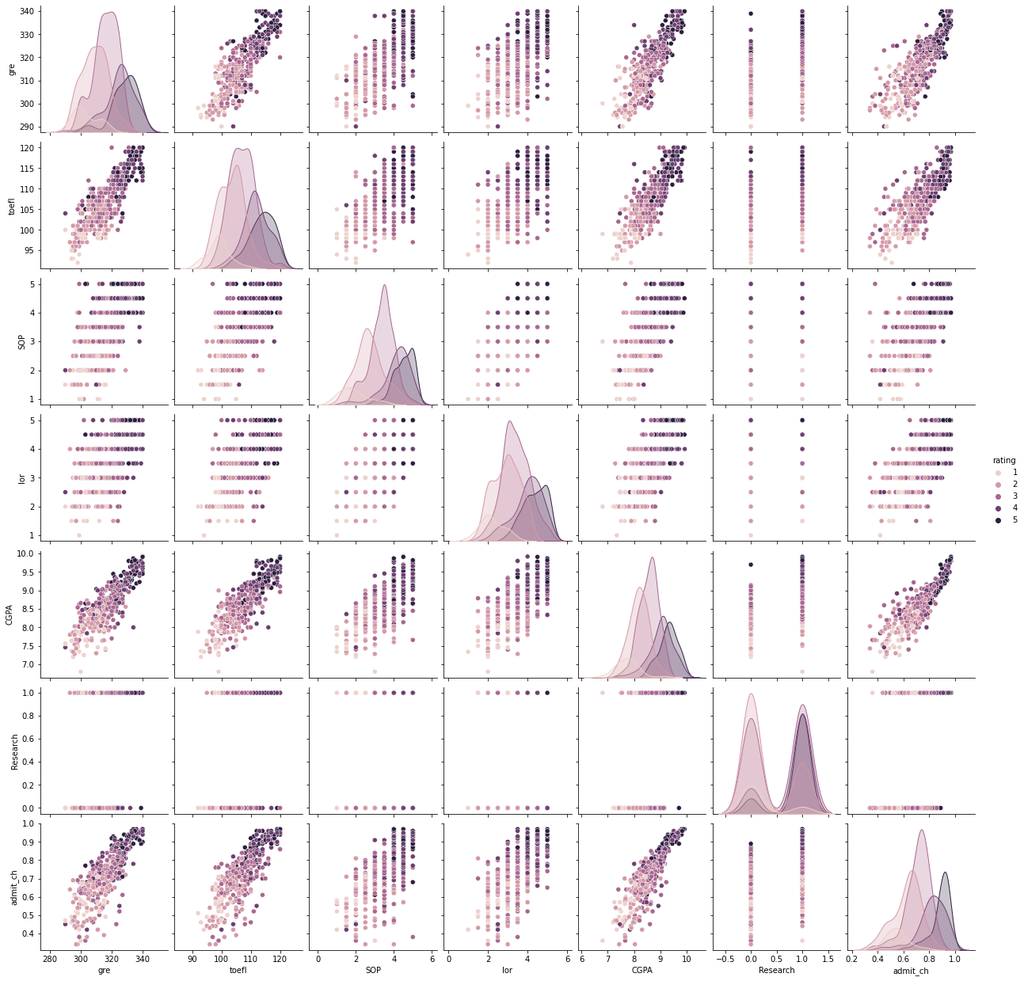

```python
sns.pairplot(data=admit, hue='rating')
```

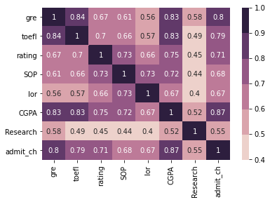

```python
sns.heatmap(admit.corr(),annot=True,cmap=sns.cubehelix_palette())
```

"Change of admission" is the key variable in this dataset. With this dataset, we will be able to tell which resume/application variables will impact one's chance to be admitted into this University.

Most measures of accomplishment are highly correlated with one another and all lead to a higher calculation for 'Change of admission'. Interestingly, having research experience seems to be the weakest determinant of other measures of academic achievement and has the lowest impact on one's chances.

Importantly, the histograms in the pairplot above reveal that the observations take on roughly normal distributions so scaling will not be necessary.

Furthermore, the relationships of all individual variables seem to be linearly correlated, so a linear regression is likely the best model.

## Task 2a (15 points):

Use scikit-learn to conduct a linear regression that models the chance of admission based on the other variables. Be sure to exclude "Serial No." as an explanatory variable. Be sure to pre-process the data appropriately. Assess how good your model is by reporting the root mean squared error (RMSE) using the test dataset from an 80-20 train-test-split of the original dataset.

```python
# no nulls value to impute or remove
admit.isnull().sum()
```

```
gre         0
toefl       0
rating      0
SOP         0
lor         0
CGPA        0
Research    0
admit_ch    0
dtype: int64
```

```python
# 1) choose appropriate class that implements what you want to do and import it
from sklearn.linear_model import LinearRegression
```

```python
# 2) choose model hyperparameters and instantiate class
lm = LinearRegression()
# hyperparameters changes resulted in worse models, leave as is.
```

```python
from sklearn.model_selection import train_test_split
```

```python
# 3) arrange data into features and labels
features = ['gre', 'toefl', 'rating', 'SOP', 'lor', 'CGPA', 'Research']
y = admit[['admit_ch']]
X = admit[features]
X_train, X_test, y_train, y_test = train_test_split(X,y,test_size=0.2, random_state=42)
```

### No Scaling

I chose not to scale after speaking with Chris. Essentially, I don't understand why one would in this case.

```python
# 4) .fit() your model to the data
model = lm.fit(X_train,y_train)
```

```python
from sklearn.metrics import mean_squared_error
```

```python
# 5) apply model to new data with .predict() for supervised learning
train_predictions = lm.predict(X_train)
train_mse = mean_squared_error(y_train, train_predictions)
train_rmse = np.sqrt(train_mse)
train_rmse # train set
```

```
0.062212714483595104
```

```python
test_predictions = lm.predict(X_test)
test_mse = mean_squared_error(y_test, test_predictions)
test_rmse = np.sqrt(test_mse)
test_rmse # test set
```

```
0.06794853476922813
```

```python
def print_margin(rmse):
    print(f'{round(rmse * 100, 1)}% from the actual score')
    print(f'{round(rmse / (0.97 - 0.34) * 100, 1)}% within the observed range')

print('training set')
print_margin(train_rmse)
print('\n')
print('testing set')
print_margin(test_rmse)
```

```
training set
6.2% from the actual score
9.9% within the observed range


testing set
6.8% from the actual score
10.8% within the observed range
```

In my view, this is a pretty good prediction given the subjective nature of admissions selection in general.

## Task 2b (5 points):

Based on your work in the previous task, what is the probability of admission for someone with a GRE score or 325, a TOEFL score of 108, a university rating of 3, an statement of purpose score of 3.0, a letter of recommendation score of 3.5, a high-school grade point average of 8.9, and who has research experience.

```python
someone = pd.DataFrame(
    np.array([[325, 108, 3, 3.0, 3.5, 8.9, 1]]),
    columns=features
)
lm.predict(someone)
```

```
array([[0.78847264]])
```

An applicant with these credentials willl have a 78.9% change of admitance.

## Task 3 (5 points):

Decide on a reasonable value for a threshold for admission. Pick a value that you would feel comfortable with if you wanted to know whether you were likely to be accepted into a graduate program. Create a new variable called "admitted" that is set to 1 if the chance of admission value is equal to or greater than your chosen threshold, 0 otherwise.

```python
threshhold = 0.80
# drop columns if thehy exist (for re-running)
admit.drop(['prediction', 'admitted'], axis=1, errors='ignore', inplace=True)
# get preditions
admit['prediction'] = lm.predict(admit.drop(columns="admit_ch"))
# check if the prediction is above the threshold
admit['admitted'] = admit['prediction'].apply(lambda t: 1 if t >= threshhold else 0)
admit.head()
```

| Serial No. | gre | toefl | rating | SOP | lor | CGPA | Research | admit_ch | prediction | admitted |
| --- | --- | --- | --- | --- | --- | --- | --- | --- | --- | --- |
| 1 | 337 | 118 | 4 | 4.5 | 4.5 | 9.65 | 1 | 0.92 | 0.946770 | 1 |
| 2 | 324 | 107 | 4 | 4.0 | 4.5 | 8.87 | 1 | 0.76 | 0.803301 | 1 |
| 3 | 316 | 104 | 3 | 3.0 | 3.5 | 8.00 | 1 | 0.72 | 0.657613 | 0 |
| 4 | 322 | 110 | 3 | 3.5 | 2.5 | 8.67 | 1 | 0.80 | 0.746042 | 0 |
| 5 | 314 | 103 | 2 | 2.0 | 3.0 | 8.21 | 0 | 0.65 | 0.638048 | 0 |

```python
admit[['admitted']].sum()
```

```
admitted    117
dtype: int64
```

```
0.8959572291310889
```

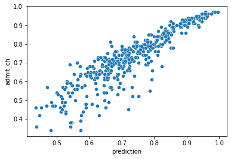

```python
sns.scatterplot(x=admit['prediction'], y=admit['admit_ch']);
print(admit['prediction'].corr(admit['admit_ch']))
```

I chose a threshold of 0.80. I chose this number after examining the output of the dendrogram in Q3. Essentially, the clustering worked out best at 0.8.

Out of curiosity, I wanted to visualize my model's "success" compared with the 'admit_ch' label. Overall it was highly correlated, giving me confidence in my model.

## Task 4 (20 points):

Using a random sample of approximately 40 rows from the original dataset, conduct an agglomerative clustering analysis using average linkage based on PCA projections of the original data onto 2 dimensions (remember to scale your data before doing the PCA). Report the percentage of variance retained in the first two principal components.

Do not use the chance of admission column or the "admitted" variable you created in the previous step in your input data.

Create a dendrogram, pick an appropriate "cut line" and comment on the composition of each of the resulting clusters. Comment on the degree to which the clusters correspond to admission probabilities (note: you may find it helpful to examine the values of "admitted").

```python
from sklearn.cluster import AgglomerativeClustering
from sklearn.preprocessing import StandardScaler
from sklearn.decomposition import PCA
from sklearn.pipeline import Pipeline
```

```python
# Authors: Mathew Kallada & Chris Teplovs
# License: BSD 3 clause
"""
=========================================
Plot Hierarachical Clustering Dendrogram
=========================================
This example plots the corresponding dendrogram of a hierarchical clustering
using AgglomerativeClustering and the dendrogram method available in scipy.
"""

import numpy as np

from matplotlib import pyplot as plt
from scipy.cluster.hierarchy import dendrogram
from sklearn.cluster import AgglomerativeClustering

def plot_dendrogram(pipeline, **kwargs):

    # Children of hierarchical clustering
    children = pipeline.named_steps.cluster.children_

    # Distances between each pair of children
    # Since we don't have this information, we can use a uniform one for plotting
    distance = np.arange(children.shape[0])

    # The number of observations contained in each cluster level
    no_of_observations = np.arange(2, children.shape[0]+2)

    # Create linkage matrix and then plot the dendrogram
    linkage_matrix = np.column_stack([children, distance, no_of_observations]).astype(float)


    # Plot the corresponding dendrogram
    dendrogram(linkage_matrix, **kwargs)

    threshold = kwargs.pop('color_threshold')
    plt.axhline(threshold,color='red')
```

```python
sample = admit.sample(40, random_state=42)
no_labels = sample.drop(columns=['prediction', 'admitted', 'admit_ch'])
```

```python
pipe = Pipeline([
    # No nulls, no Imputer
    ('scale',StandardScaler()),
    ('pca', PCA(n_components=2,random_state=42)),
    ('cluster', AgglomerativeClustering(n_clusters=2)),
])

y_pred = pipe.fit_predict(no_labels)
sum(pipe.named_steps.pca.explained_variance_ratio_)
```

```
0.8134733313600961
```

[figure not shown]

```python
plt.figure(figsize=(14,10))
plt.title('Hierarchical Clustering Dendrogram (Students)')

plot_dendrogram(pipe,labels=sample.admitted.to_numpy(),color_threshold=38)
plt.axhline(57.5,c='red')
plt.xticks(rotation=0)
plt.show()
```

I added the 'admitted' column values to the labels for each observation. This gave me a sense of how the admitted status determined by my threshold arranged themselves into groups. After playing with the threshold value a bit, I was delighted to find that with a cut line of 38, there were only 2 groups and all admitted students fell into 1 group. There were no admissions in the other group.

## Task 5 (20 points):

Conduct a k-means clustering of the complete admissions data. Pre-process the data using a 2-dimensional PCA (remember to scale your data before doing the PCA). Again, do not use the chance of admission or the "admitted" variable you created earlier. Use the average silhouette score to determine the optimal number of clusters and show the silhouette plot for the optimal number of clusters.

```python
from sklearn.cluster import KMeans
from sklearn.metrics import silhouette_samples, silhouette_score

import matplotlib.pyplot as plt
import matplotlib.cm as cm # colormaps
import numpy as np

def plot_silhouettes(features, pipeline, cluster_list=[2, 3, 4, 5, 6]):
    for n_clusters in cluster_list:
        # Create a subplot with 1 row and 2 columns
        fig, (ax1, ax2) = plt.subplots(1, 2)
        fig.set_size_inches(18, 7)

        # The 1st subplot is the silhouette plot
        # The silhouette coefficient can range from -1, 1 but in this example all
        # lie within [-0.1, 1]
        ax1.set_xlim([-0.1, 1])
        # The (n_clusters+1)*10 is for inserting blank space between silhouette
        # plots of individual clusters, to demarcate them clearly.
        ax1.set_ylim([0, len(features) + (n_clusters + 1) * 10])

        # Initialize the clusterer with n_clusters value and a random generator
        # seed of 42 for reproducibility.

        pipeline.named_steps.cluster.set_params(n_clusters=n_clusters)
        clusterer = pipeline.named_steps.cluster
        cluster_labels = clusterer.fit_predict(features)

        # The silhouette_score gives the average value for all the samples.
        # This gives a perspective into the density and separation of the formed
        # clusters
        silhouette_avg = silhouette_score(features, cluster_labels)
        print("For n_clusters =", n_clusters,
              "The average silhouette_score is :", silhouette_avg)

        # Compute the silhouette scores for each sample
        sample_silhouette_values = silhouette_samples(features, cluster_labels)

        y_lower = 10
        for i in range(n_clusters):
            # Aggregate the silhouette scores for samples belonging to
            # cluster i, and sort them
            ith_cluster_silhouette_values = sample_silhouette_values[cluster_labels == i]

            ith_cluster_silhouette_values.sort()

            size_cluster_i = ith_cluster_silhouette_values.shape[0]
            y_upper = y_lower + size_cluster_i

            color = cm.nipy_spectral(float(i) / n_clusters)
            ax1.fill_betweenx(np.arange(y_lower, y_upper),
                              0, ith_cluster_silhouette_values,
                              facecolor=color, edgecolor=color, alpha=0.7)

            # Label the silhouette plots with their cluster numbers at the middle
            ax1.text(-0.05, y_lower + 0.5 * size_cluster_i, str(i))

            # Compute the new y_lower for next plot
            y_lower = y_upper + 10  # 10 for the 0 samples

        ax1.set_title("The silhouette plot for the various clusters.")
        ax1.set_xlabel("The silhouette coefficient values")
        ax1.set_ylabel("Cluster label")

        # The vertical line for average silhouette score of all the values
        ax1.axvline(x=silhouette_avg, color="red", linestyle="--")

        ax1.set_yticks([])  # Clear the yaxis labels / ticks
        ax1.set_xticks([-0.1, 0, 0.2, 0.4, 0.6, 0.8, 1])

        # 2nd Plot showing the actual clusters formed
        colors = cm.nipy_spectral(cluster_labels.astype(float) / n_clusters)
        ax2.scatter(features.values[:, 0], features.values[:, 1], marker='.', s=30, lw=0, alpha=0.7,
                    c=colors, edgecolor='k') #here 4

        # Labeling the clusters
        centers = clusterer.cluster_centers_
        # Draw white circles at cluster centers
        ax2.scatter(centers[:, 0], centers[:, 1], marker='o',
                    c="white", alpha=1, s=200, edgecolor='k')

        for i, c in enumerate(centers):
            ax2.scatter(c[0], c[1], marker='$%d$' % i, alpha=1,
                        s=50, edgecolor='k')

        ax2.set_title("The visualization of the clustered data.")
        ax2.set_xlabel("Feature space for the 1st feature")
        ax2.set_ylabel("Feature space for the 2nd feature")

        plt.suptitle(("Silhouette analysis for KMeans clustering on sample data "
                      "with n_clusters = %d" % n_clusters),
                     fontsize=14, fontweight='bold')

    plt.show()
```

```
For n_clusters = 2 The average silhouette_score is : 0.5674442199663338
For n_clusters = 3 The average silhouette_score is : 0.4997125179170462
For n_clusters = 4 The average silhouette_score is : 0.5964834350420798
For n_clusters = 5 The average silhouette_score is : 0.49614008791418734
For n_clusters = 6 The average silhouette_score is : 0.43983377975450894
```

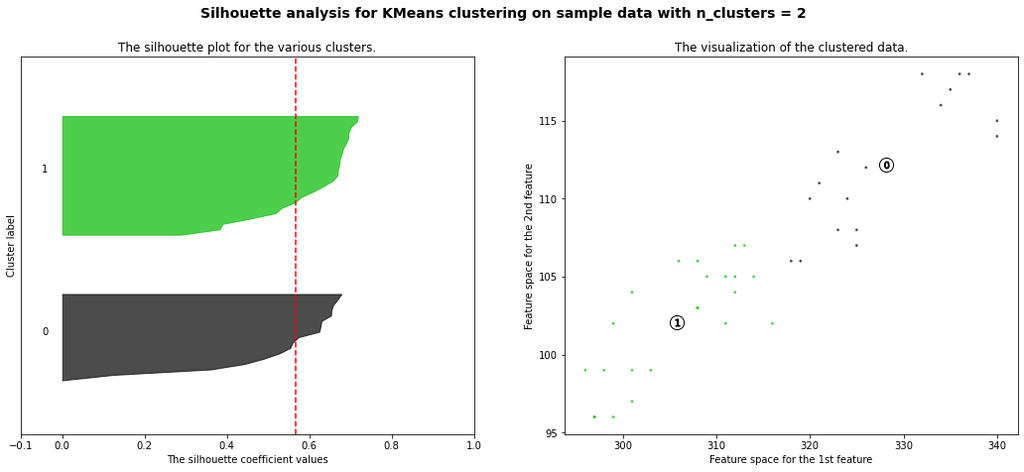

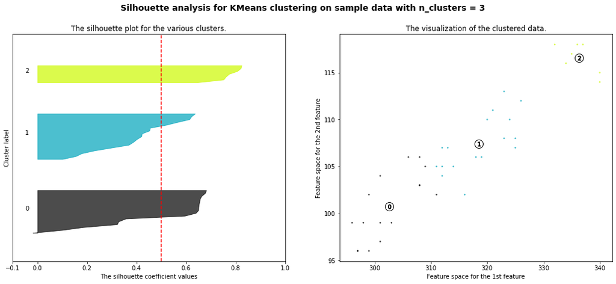

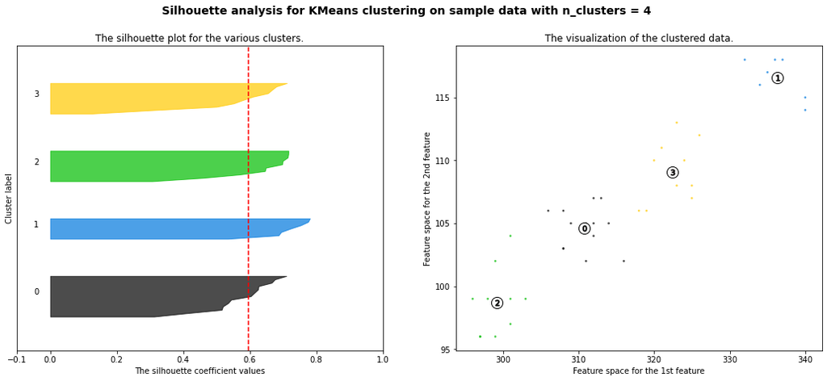

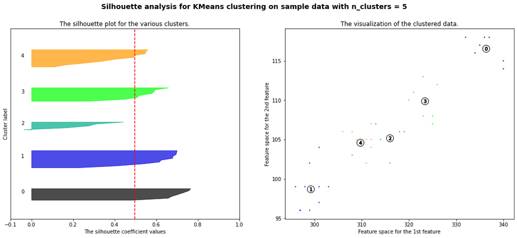

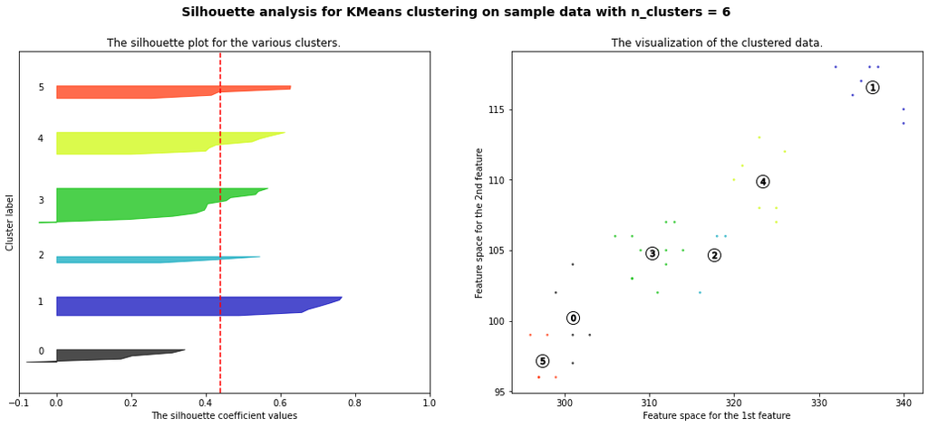

```python
# I wasn't sure given the instructions, but I decided to reuse the sample of 40 from Q4.
plot_silhouettes(no_labels, Pipeline([
    ('scale',StandardScaler()),
    ('pca', PCA(n_components=5,random_state=42)),
    ('cluster', KMeans(n_clusters=2)),
]))
```

The best choice silhouette score resulted when n_clusters=4, meaning that 4 clusters is the most optimal choice. That finding corresponds to the nicely 'machete' shaped silhouette plot in that figure meaning that most observations are close to the centroid of the cluster to which they are assigned.

## Task 6 (10 points):

Show the results of a t-SNE analysis of the complete admissions data. As before, do not use the chance of admission column or the "admitted" variable you created in the previous step in your input data. Color the points in your visualization based on the "admitted" variable you created earlier.

```python
from sklearn.manifold import TSNE
```

```python
complete = admit.drop(columns=['prediction', 'admitted', 'admit_ch'])
tsne = TSNE(n_components=2, random_state=0, perplexity=50, n_iter=1000)
X_2d = tsne.fit_transform(complete)
```

```python
# decrease indicies by 1 to match t-sne output
temp_admit = admit.copy()
temp_admit.index -= 1
```

```python
tsne_labelled = pd.concat([pd.DataFrame({'admitted':temp_admit['admitted']}),pd.DataFrame(X_2d,columns=['d1','d2'])],axis=1)
tsne_labelled.head()
```

|  | admitted | d1 | d2 |
| --- | --- | --- | --- |
| 0 | 1 | -18.412983 | -13.041513 |
| 1 | 1 | -5.537402 | -5.055808 |
| 2 | 0 | 1.276299 | 2.950103 |
| 3 | 0 | -6.499476 | -2.974746 |
| 4 | 0 | 3.005020 | 4.894023 |

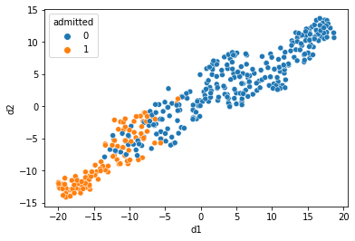

```python
sns.scatterplot(data=tsne_labelled,x='d1',y='d2', hue='admitted');
```

Although there is some overlap between the groupings of admitted and non-admitted students, there is still a clear relationship. The lower the value along either axis, the higher the probability of admittance.

I experimented with perplexities between 5 and 60 and interactions between 1000 and 3000. Ultimately the number of iterations did not affect the output very much. Perplexity between 30 and 50 grouped the observations by 'admitted' very well, however, I chose 50 because of the tightness of the observations and color groups.

# NOTE

We **strongly** recommend restarting your kernel and running your complete notebook from top to bottom before submitting your work to Canvas in both HTML and IPYNB formats.